# CMIP6 evaluation of AOD against ground-based observations and MERRA2

**Franziska Hellmuth**

franziska.hellmuth@geo.uio.no

Group 2

Paul Glantz, Ksenia Tabakova, Jonas Gliss

*My results of Aerosol optical depth will take your breath*

# Motivation

[output not shown]

- Seasonal variation over Svalbard area
- Lowest AOD during summer
- CMIP5 against remote sensing
  - $\rightarrow$ underestimation during spring
  - $\rightarrow$ overestimation during winter

**What is the performance of the models in the IPCC CMIP6 project in terms of AOD simulated over**

- Svalbard region?

- Arctic?

# Observations, Re-Analysis, historical simulation of CMIP6

### AERONET (AERosol RObotic NETwork)

- Sunphotometer at Arctic Station lat > 66$^{\circ}$N (total 14)

### MERRA2 (Modern-Era Retrospective analysis for Research and Applications 2)

- satellite reanalysis since 1980
- horizontal resolution: 0.5 - 0.625 $^{\circ}$

| CMIP6 Models |  |
| --- | --- |
| GFDL-CM4 | E3SM-1-0 |
| **CanESM5** | MIROC-ES2L |
| **NorESM2-LM** | CNRM-CM6-1 |
| CESM2-WACCM | IPSL-CM6A-LR |
| **GFDL-ESM4** | CESM2 |

# Validation of AOD from MERRA2 with AERONET

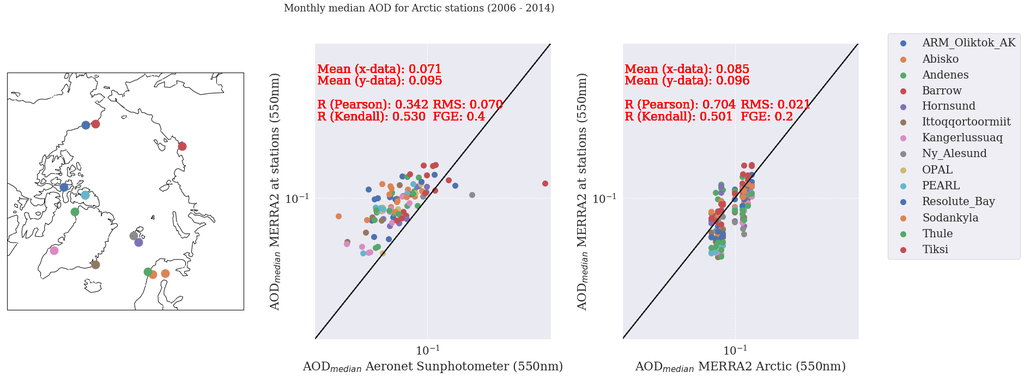

# Evaluation of Arctic AOD from CMIP6 to MERRA2

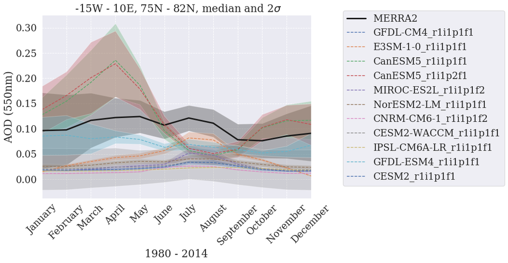

# AOD evaluation for Svalbard Region

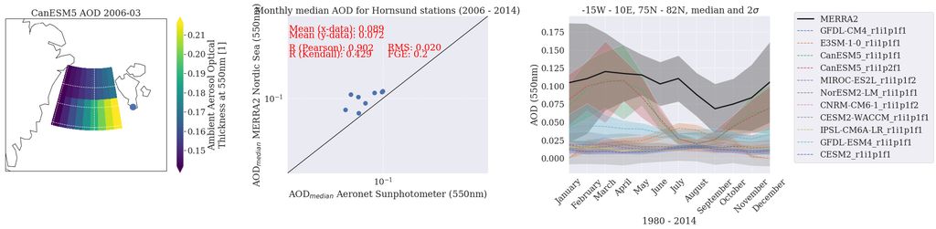

# AOD zonal evaluation

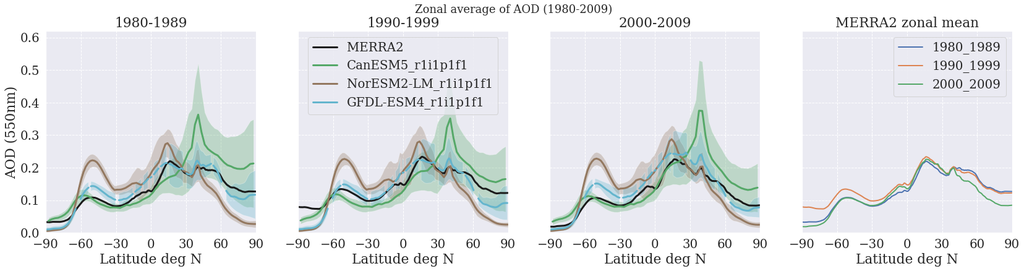

**Fig. 6:** Zonal average of AOD for 1980-89, 1990-99, 2000-09. Evaluation for CanESM5, NorESM2-LM, GFDL-ESM.

# Conclusion & Future Work

### AERONET - MERRA2

- MERRA2 is higher than AERONET AOD
- MERRA2 'stations' compare well to Arctic AOD average

### MERRA2 - CMIP6

- Arctic
  - CanESM5 overestimates during spring, too low during summer
  - still underestimation during spring
- Svalbard region
  - CanESM5 within MERRA2 variability

### Zonal average

- overestimation in NH (CanESM5)
- overestimation in SH (NorESM2-LM)
- $\rightarrow$ compare all models, correlate the ones which fit will $\rightarrow$ Why do they fit better?

**Thank you!**